# RNA-seq数据聚类分析

分子细胞科学卓越创新中心生物信息平台

11 June 2020

#### Abstract

本文描述了bulk RNA-seq分析流程中聚类子模块，该模块根据基因的表达量，将表达模式相近的样本聚在一起。该模块用R语言编写。

# 1 分析流程示意图

该模块只需要输入样本的基因表达量，使用DataSummary模块生成的*_raw.RData作为输入文件来完成聚类，如下图所示:

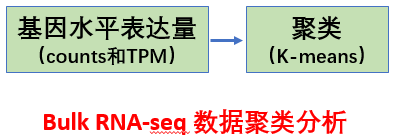

# 2 输出

## 2.1 聚类热图

Silhouette Coefficient 折线图：

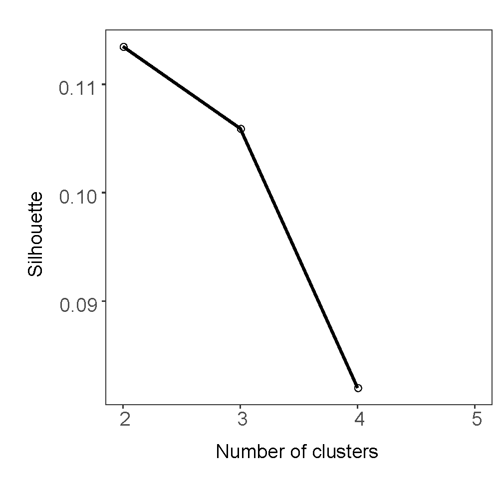

聚类热图：

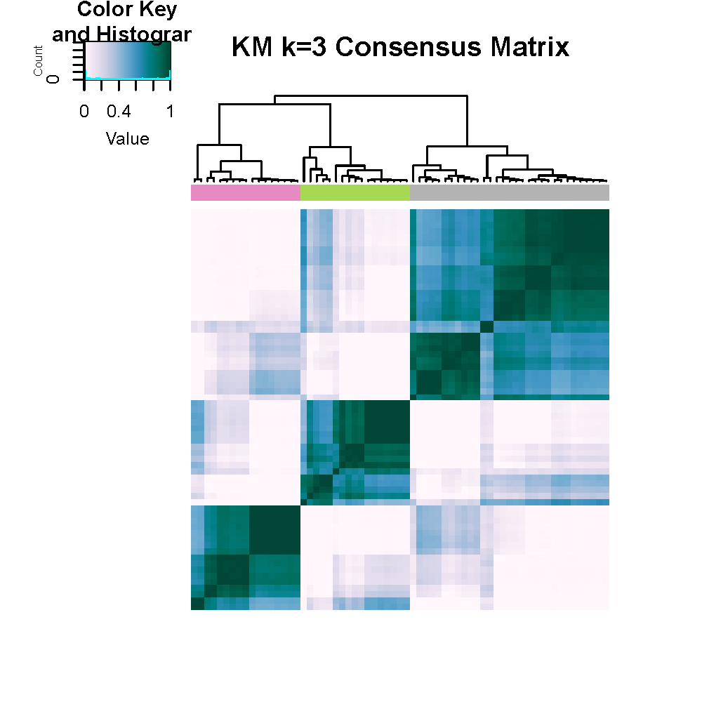

## 2.2 聚类表格

该模块保留样本聚类的结果到*clustering.txt文件中，详细记录了K取不同值时，样本的聚类分组情况，具体内容如下表所示：

|  | group | C2 | C3 | C4 | C5 |
| --- | --- | --- | --- | --- | --- |
| 1302003-C | Cancer | 1 | 1 | 1 | 1 |
| 1302003-N | Normal | 2 | 2 | 2 | 2 |
| 1436156-C | Cancer | 1 | 3 | 3 | 3 |
| 1436156-N | Normal | 2 | 2 | 2 | 2 |
| 1436468-C | Cancer | 1 | 1 | 1 | 1 |

注：  
第1列：样本；  
第2列：样本分组；  
第3-6列：K分别取值2-5时样本的聚类情况。

# 3 参考文献

- [1] Chiu, D.S., Talhouk, A. diceR: an R package for class discovery using an ensemble driven approach.BMC Bioinformatics 19, 11 (2018).
- [2] Coates A., Ng A.Y. (2012) Learning Feature Representations with K-Means. In: Montavon G., Orr G.B., Müller KR. (eds) Neural Networks: Tricks of the Trade. Lecture Notes in Computer Science, vol 7700. Springer, Berlin, Heidelberg.
- [3] Peter, J, Rousseeuw. Silhouettes: A graphical aid to the interpretation and validation of cluster analysis[J]. Journal of Computational and Applied Mathematics, 1987.